# unidad 1

## 11. Con la base de datos crabs del paquete MASS de R, realizar un matriz de diagramas de dispersión según especie y sexo con la instrucción pairs().

1. Añadir los histogramas de cada variable a la diagonal.
2. Añadir la recta de regresión a cada diagrama de dispersión.

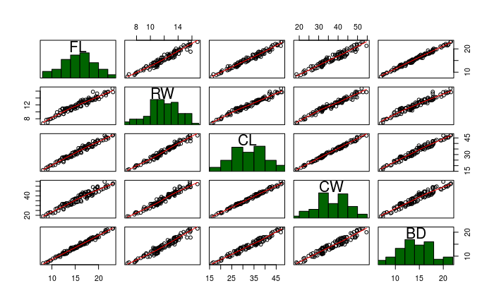

```r
panel.hist <- function(x, ...)
{
    usr <- par("usr"); on.exit(par(usr))
    par(usr = c(usr[1:2], 0, 1.5) )
    h <- hist(x, plot = FALSE)
    breaks <- h$breaks; nB <- length(breaks)
    y <- h$counts; y <- y/max(y)
    rect(breaks[-nB], 0, breaks[-1], y, col = "darkgreen", ...)
}

crabs %>%
    filter(sex == 'M') %>%
    select(4:8) %>%
    pairs(., panel = panel.smooth, diag.panel = panel.hist)
```

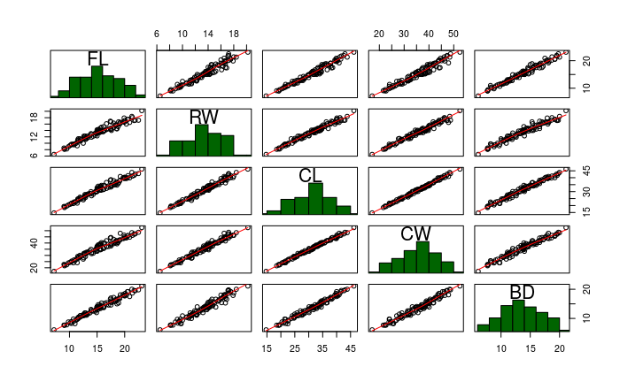

```r
crabs %>%
    filter(sex == 'F') %>%
    select(4:8) %>%
    pairs(., panel = panel.smooth, diag.panel = panel.hist)
```

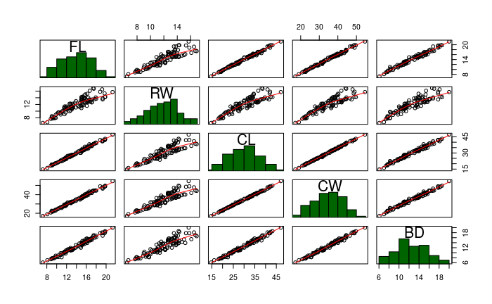

```r
crabs %>%
    filter(sp == 'B') %>%
    select(4:8) %>%
    pairs(., panel = panel.smooth, diag.panel = panel.hist)
```

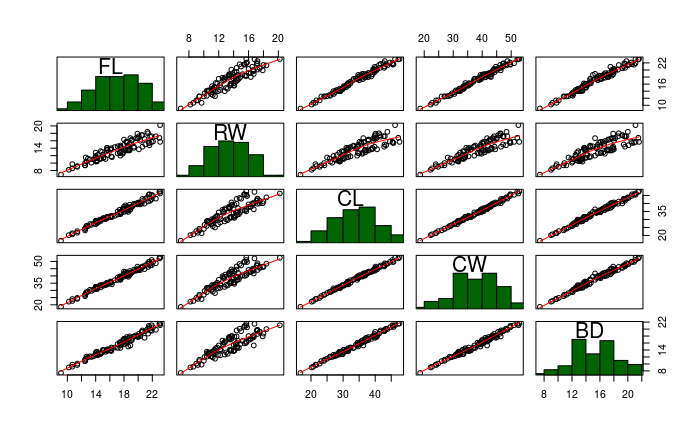

```r
crabs %>%
    filter(sp == 'O') %>%
    select(4:8) %>%
    pairs(., panel = panel.smooth, diag.panel = panel.hist)
```

## 12. Con la base de datos huswif del libro de Everitt(2005):

1. Calcular algún gráfico de dispersión 3D con la función scatterplot3d() del paquete scatterplot3d.
2. Realizar un gráfico de dispersión en dos dimensiones de las variables edad del marido y edad de la mujer. Añadir con la función symbols() la variable edad del marido en el primer matrimonio.

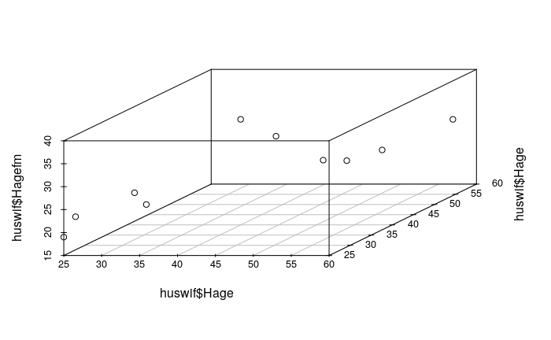

```r
source('https://www.york.ac.uk/depts/maths/data/everitt/chap1huswif.dat')
pacman::p_load(scatterplot3d)

# a)
scatterplot3d(huswif$Hage, huswif$Hage, huswif$Hagefm)
```

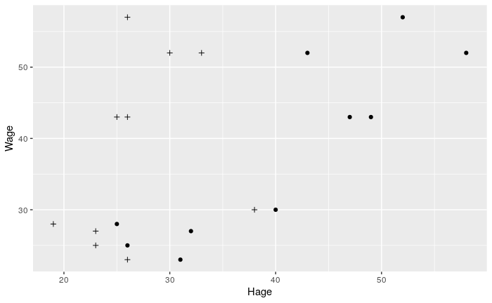

```r
# b)
huswif %>%
    ggplot(aes(Hage, Wage)) +
    geom_point() +
    geom_point(aes(x = Hagefm), shape = 3)
```

## 13. (*) Representar con caras de Chernoff las parejas de la base de datos huswif del libro de Everitt(2005).

```
effect of variables:
 modified item       Var
 "height of face   " "Hage"
 "width of face    " "Hheight"
 "structure of face" "Wage"
 "height of mouth  " "Wheight"
 "width of mouth   " "Hagefm"
 "smiling          " "Hage"
 "height of eyes   " "Hheight"
 "width of eyes    " "Wage"
 "height of hair   " "Wheight"
 "width of hair   "  "Hagefm"
 "style of hair   "  "Hage"
 "height of nose  "  "Hheight"
 "width of nose   "  "Wage"
 "width of ear    "  "Wheight"
 "height of ear   "  "Hagefm"
```

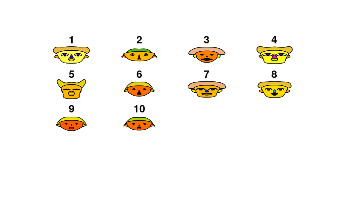

```r
pacman::p_load(aplpack)
aplpack::faces(huswif)
```